# SwiftKey Exploratory Data Analysis: English Language Data

Akhil Kota

2022-08-14

## Overview

This milestone report investigates the English language data set provided by the SwiftKey team, which includes corpora from news, blogs, and Twitter. We first investigate the files themselves and their general contents. Then, word and 2-gram distributions in each of the data sets are visualized to better understand the data. Note that a training set size of 80% of the overall data is used for exploratory analysis, after initial data file summary stats.

## Processing the Data and File Summary Stats

Prior to visualization, we will detail the procedure involved in processing the data. The standard way of processing text data for computer analysis and prediction is tokenization, which is the process of splitting the text into chunks (sentences, n-grams, or words) in a standardized way and making computer-readable tokens out of them. This is done so that the computer can read and analyze the data in an accurate fashion. For our purposes, the tidy text package from the Comprehensive R Archive Network (CRAN) is used for this pre-processing and tokenization of the available data. The code below performs this procedure, and leaves ID’s to track the file, line, sentence, and word. We first tokenize sentences, then words.

```r
news_df <- data.frame(type_id="news", line = news) %>% mutate(line_id = row_number())
twitter_df <- data.frame(type_id="twitter", line = twitter) %>% mutate(line_id = row_number())
blogs_df <- data.frame(type_id="blogs", line = blogs) %>% mutate(line_id = row_number())
df <- rbind(news_df, twitter_df, blogs_df)
rm(list=c("blogs","blogs_df","news","news_df","twitter","twitter_df"))

sentences <- unnest_sentences(df, sentence, line) %>% mutate(type_id = factor(type_id), sentence_id = row_number())
rm("df")

words <- unnest_tokens(sentences, word, sentence) %>% mutate(word_id = as.numeric(factor(word)))
```

Below is a quick peak at each data file by line count, sentence count, and word count.

```
## # A tibble: 4 × 4
##   file_type line_count sentence_count word_count
##   <chr>          <int>          <dbl>      <int>
## 1 blogs         899288        2375718   37546250
## 2 news         1010242        2024588   34762395
## 3 twitter      2360148        3770155   30093374
## 4 TOTAL        4269678        8170461  102402019
```

Although blogs have the lowest line count, we see that they actually have the highest word count of the three. Twitter data has predictably low words per line on average, likely due to Twitter’s famous character limit.

## Visualizing Single Word Data

Now we will focus in on our training data set and investigate the distribution and frequencies of words. We will first look at the top overall word frequencies across the data files.

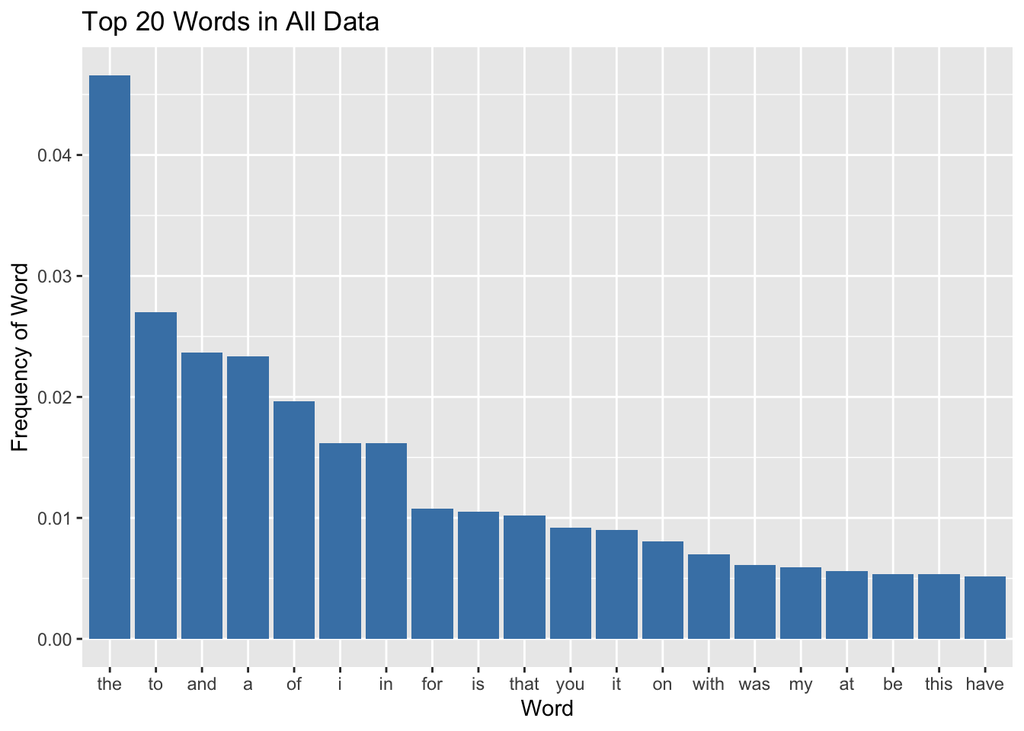

Unsurprisingly, words like “the”, “to”, and “and” top our list. “the” seems particularly dominant. There is a noticeable interesting drop-off between “in” and “for”, but we can’t really interpret this in any other useful way. Next, we will visualize the top words after omitting “stop words”, which are words like “the” and “and” that do not really add much information to the text, but are used mainly for grammar. The table below shows the frequency of stop words by data file. We use the [stop_words set available in the tidy text package](http://snowball.tartarus.org/algorithms/english/stop.txt) to analyze this.

```
## # A tibble: 3 × 2
##   file_type stop_word_proportion
##   <fct>                    <dbl>
## 1 blogs                    0.612
## 2 news                     0.529
## 3 twitter                  0.585
```

Interestingly, the blogs data have the highest proportion of stop words, and the news data have the least. Either way, a majority of every file consists of stop words. Removing these, we get the top 20 words across data sets shown below.

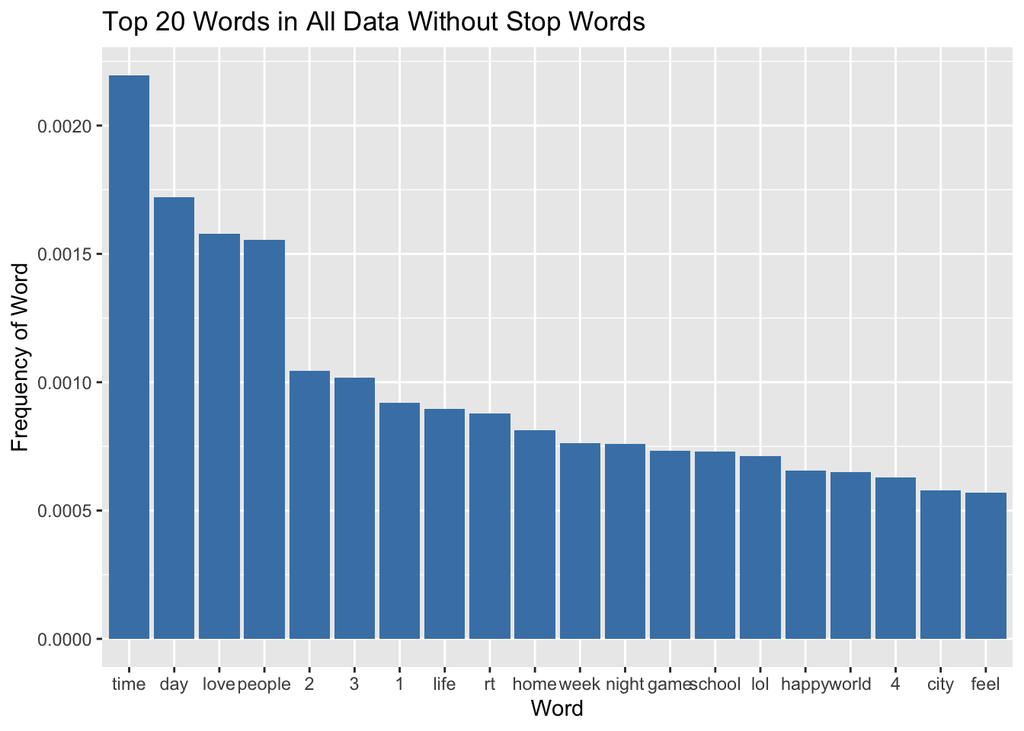

We see an interesting mix of words, and some that seem specific to a certain data file (such as “rt” used in Twitter). We also see a several numbers, which are retained as words by the previous pre-processing and tokenization processes, although special characters have been removed.

Since we have started seeing some file-specific data popping up, let’s now look at word frequencies by type of data (news, blogs, or Twitter). Below are some word clouds of the top 20 words in each data set, with and without stop words.

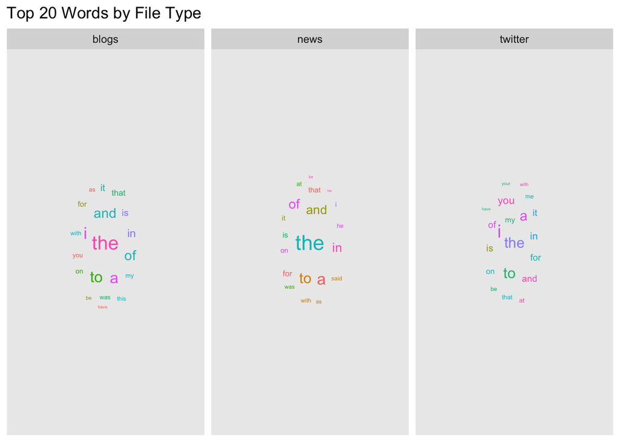

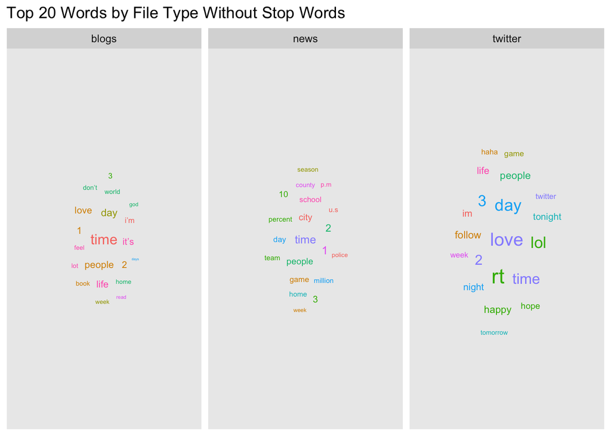

With stop words, the top words present in each of the data sets are relatively similar, with the exception of more personal pronouns in the Twitter and blog data. Without stop words, the top words of each data set considerably diverge. Both blogs and tweets have more personal topics, such as love and other emotions. Blogs and tweets differ in the type of language used, most notable in the presence of “im” in the top Twitter words and “i’m” in the top blog words. The top news words seem to revolve around location, time, and statistics, which is par for the course. Note that the pre-processing also makes all words lowercase by default, hence the appearance of the words.

Lastly, we take a look at the distribution of frequencies (in particular, how the word frequencies descend in our data set). We can then tell how large of a vocabulary would cover different percentiles of the data set.

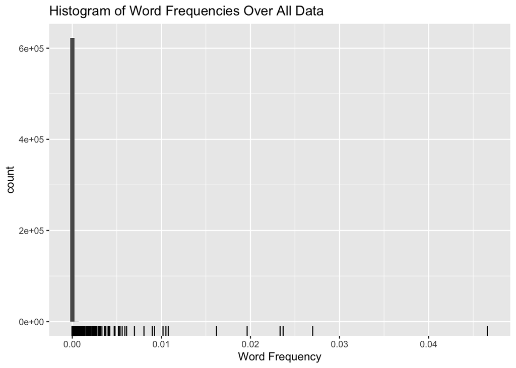

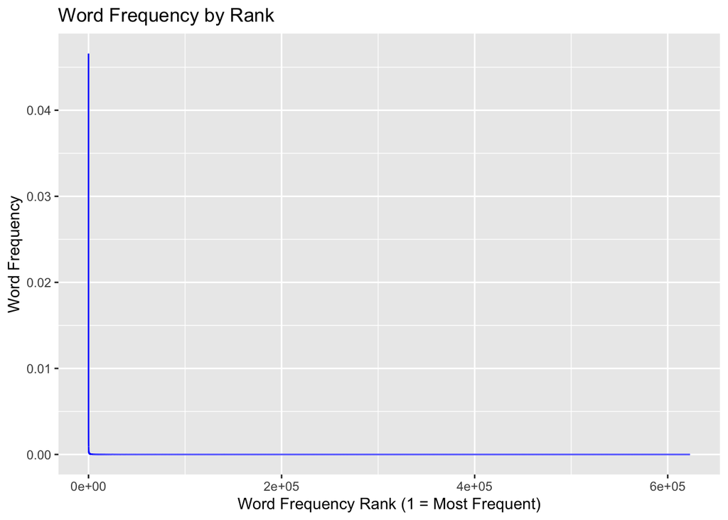

As expected, the distribution is extremely skewed right, with most words being very rare and some words extremely common. The rug plot below the histogram illustrates this very well. This skewness is remedied below by instead visualizing the frequency of the words on a log-10 scale.

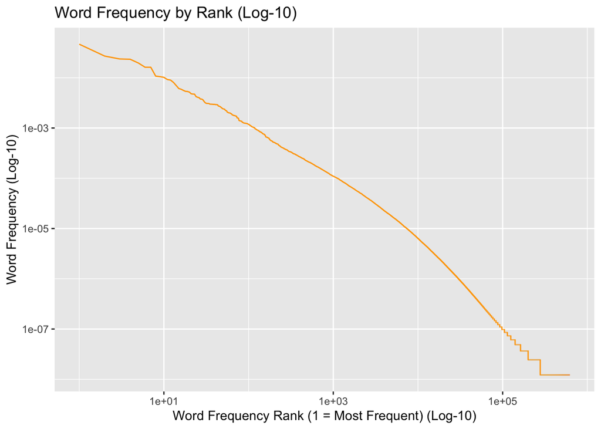

Now we get a better picture of the distribution. Below is a plot of the cumulative distribution of frequencies in the log-10 scale, along with a table of coverage percentiles denoting the smallest possible vocabulary that covers each percent of words in the data set.

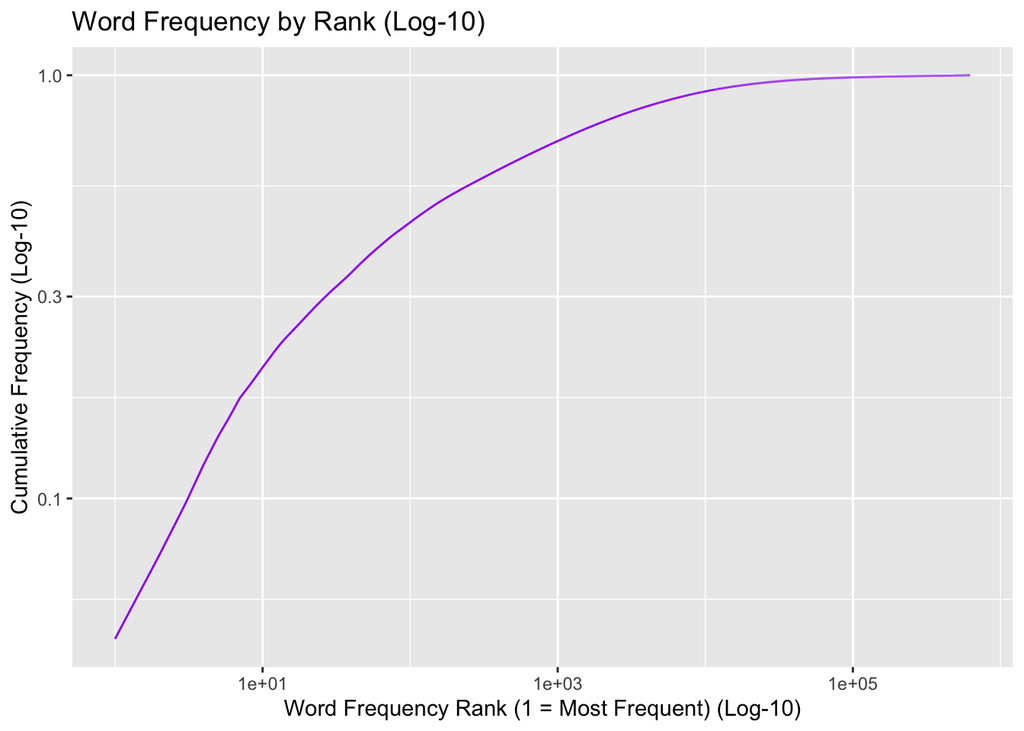

```
## # A tibble: 12 × 2
##    percent_coverage number_of_words
##               <dbl>           <int>
##  1             10                 4
##  2             20                10
##  3             30                27
##  4             40                66
##  5             50               156
##  6             60               404
##  7             70              1009
##  8             80              2542
##  9             90              7922
## 10             95             19109
## 11             99            118275
## 12             99.9          541169
```

## Visualizing Bigram Data

Visualizing bigrams (groups of 2 words, also known as 2-grams) can give us some clues about how words are typically grouped together for our prediction algorithm. In this section, we will visualize bigram frequencies and relationships across and within the three data sets we have.

The most common bigrams across all data are given below, along with the total number of unique bigrams.

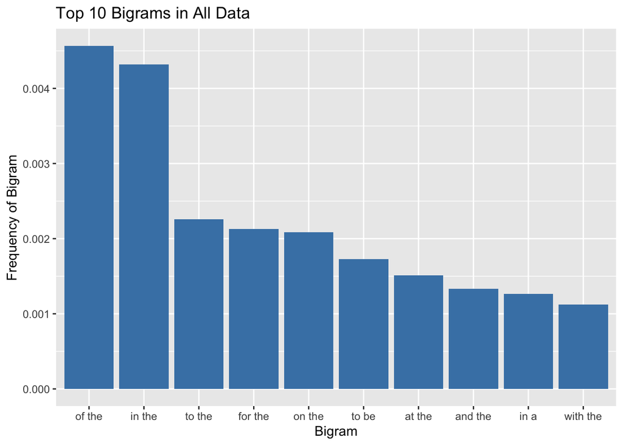

```
##                         count
## Total Unique Bigrams 11571200
```

For bigrams, we can also produce graph-like charts that show the most common links between words. This is done with the igraph and ggraph packages. Below, we have produced such a graph for the top 100 bigrams in throughout the data.

```
## Using `stress` as default layout
```

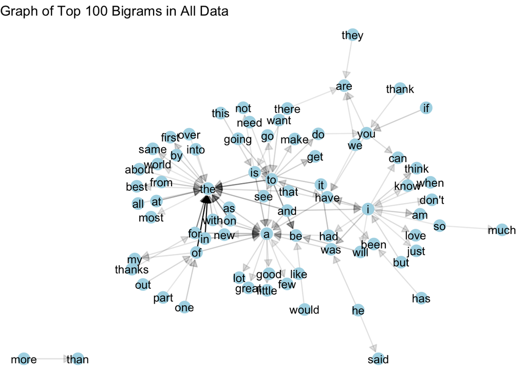

The arrows in the plot above directionally point from the first word to the second word of the bigram. We see that “the” is a major node, as a member in many of the most common bigrams. We also see that the tree is relatively connected, with the only top 100 bigram not connected to any other word being “more than”. Below is a similar tree of bigrams, this time with neither word being a stop word.

```
## Multiple parents. Unfolding graph
```

```
## Multiple roots in graph. Choosing the first
```

```
## Using `tree` as default layout
```

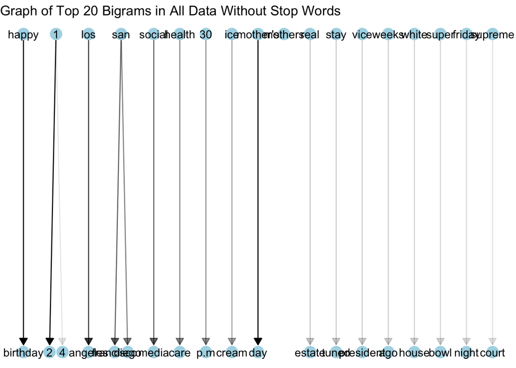

We generally see very few common edges between words. The most common non-stop-word bigrams seem to be proper nouns or common two-word phrases. Stop words, although lacking in meaning, are the main connectors in language, so it makes sense that we see very few cross-bigram connections in the above graph.

## Next Steps

After exploring the training data set, we have a good sense for what is in it and the general distribution of language across each data file type (news, blogs, Twitter). The next step is to begin crafting the predictive model using n-gram data from our data set. We will be applying a probabilistic language model to the data set, recording counts of n-grams to infer probabilities of these n-grams for prediction. We will also test some enhancing mechanisms to better our predictions, such as part-of-speech tagging and sentiment analysis.

Challenges for the model include out-of-vocabulary words/data, data size, and algorithm runtime. Although runtime will likely not be a huge deal for our model, we may need to sample the data in an intelligent, random way to create the model, or read and process the data in chunks over a period of time to “train” the model. There are several methods for dealing with out-of-vocabulary words, including additive smoothing, backoff models, and out-of-vocabulary word tags. These will be investigated further in the modeling notebook of this project, and described in the documentation of the final model.